[video not shown]

# P&G Stock Price Prediction using Monte Carlo Simulation

# P&G Stock Price Prediction using Monte Carlo Simulation

In this project, we aim to predict the future price of PG stock over the next 1000 days. We use a Monte Carlo simulation, a computational algorithm that relies on repeated random sampling to obtain numerical results.

## Data Acquisition and Preparation

In this section, we're going to import the necessary libraries and download the historical data for the PG stock.

```python
import numpy as np
import pandas as pd

import matplotlib.pyplot as plt
%matplotlib inline

import seaborn as sns
# Set the style and context of the plot
sns.set_style("whitegrid")
sns.set_context("notebook")

import yfinance as yf
from scipy.stats import norm
```

```python
df = pd.DataFrame()
df['PG'] = yf.download('PG', start='2007-1-1')['Adj Close']
```

```
[*********************100%***********************]  1 of 1 completed
```

```python
df.head()
```

| Date | PG |
| --- | --- |
| 2007-01-03 | 39.827557 |
| 2007-01-04 | 39.525192 |
| 2007-01-05 | 39.185783 |
| 2007-01-08 | 39.272190 |
| 2007-01-09 | 39.173439 |

```python
log_returns = np.log(1 + df.pct_change())
log_returns.tail()
```

| Date | PG |
| --- | --- |
| 2023-09-25 | -0.006088 |
| 2023-09-26 | -0.008934 |
| 2023-09-27 | -0.013349 |
| 2023-09-28 | -0.006810 |
| 2023-09-29 | -0.003285 |

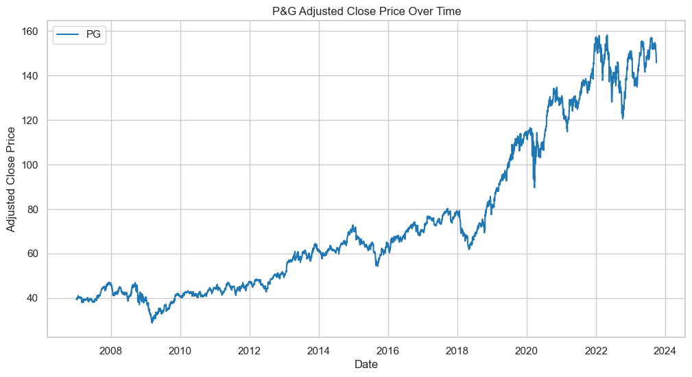

```python
# Create the plot
plt.figure(figsize=(12,6))
sns.lineplot(data=df)

# Add title and labels
plt.title('P&G Adjusted Close Price Over Time')
plt.xlabel('Date')
plt.ylabel('Adjusted Close Price')
```

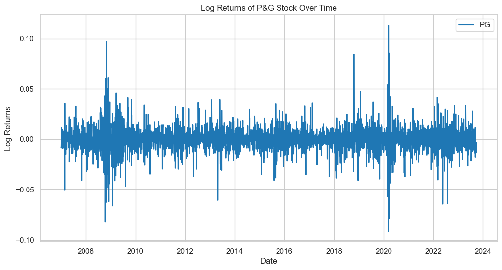

```python
plt.figure(figsize=(12,6))
sns.lineplot(data=log_returns)

# Add title and labels
plt.title('Log Returns of P&G Stock Over Time')
plt.xlabel('Date')
plt.ylabel('Log Returns')
```

## Calculating Daily Returns

In this section, we calculate the daily returns using the formula `np.exp(drift.values + stdev.values * norm.ppf(np.random.rand(t_intervals, iterations)))`. This formula takes into account the drift (the direction of the stock price) and the standard deviation (the volatility of the stock price).

```python
u = log_returns.mean()
u
```

```
PG    0.000308
dtype: float64
```

```python
var = log_returns.var()
var
```

```
PG    0.000138
dtype: float64
```

```python
drift = u - (.5 * var)
drift
```

```
PG    0.000239
dtype: float64
```

```python
drifttt = log_returns.mean() - (.5 * log_returns.var())
```

```python
stdev = log_returns.std()
stdev
```

```
PG    0.011752
dtype: float64
```

```python
np.array(drift)
```

```
array([0.00023899])
```

```python
type(drift)
```

```
pandas.core.series.Series
```

```python
drift.values
```

```
array([0.00023899])
```

```python
stdev.values
```

```
array([0.01175193])
```

```python
norm.ppf(.95)
```

```
1.6448536269514722
```

```python
x = np.random.rand(10,2)
x
```

```
array([[0.88215587, 0.26740085],
       [0.99691613, 0.1670872 ],
       [0.33619386, 0.99865719],
       [0.93946017, 0.40313387],
       [0.54572297, 0.34167402],
       [0.73763826, 0.29461943],
       [0.42793181, 0.81223013],
       [0.99594291, 0.82562014],
       [0.32388112, 0.83360657],
       [0.38623094, 0.39216722]])
```

```python
norm.ppf(x)
```

```
array([[ 1.18583299, -0.6206929 ],
       [ 2.73872751, -0.96573979],
       [-0.42287327,  3.00160374],
       [ 1.55025775, -0.24524369],
       [ 0.11486257, -0.4078987 ],
       [ 0.63608123, -0.53993935],
       [-0.18164209,  0.88614435],
       [ 2.64728147,  0.93699776],
       [-0.45687311,  0.96851573],
       [-0.28915617, -0.27367495]])
```

```python
z = norm.ppf(np.random.rand(10,2))
z
```

```
array([[ 1.38554927e-01, -1.19051671e+00],
       [ 1.52626341e+00,  1.46380439e+00],
       [ 8.39639665e-01, -2.04613555e-02],
       [-7.95443145e-01, -1.20088826e+00],
       [-6.13151048e-02,  8.18954648e-02],
       [-6.52476798e-01,  2.57709474e+00],
       [ 2.98645406e-01,  2.14207107e+00],
       [ 2.15923085e-03, -1.82837927e-01],
       [ 1.53608428e-01, -6.40654739e-02],
       [-2.63792772e-01,  3.41458471e-01]])
```

1. **Setting up Time Intervals and Iterations**

```python
t_intervals = 1000 # forecasting the stock price for the comming 1000 days
iterations = 10 # produce 10 predections of the stock
```

$$ daily\_returns = e^{r} $$$$ r = drift + stdev \cdot z $$

1. **Calculating Daily Return**

```python
daily_return = np.exp(drift.values + stdev.values * norm.ppf(np.random.rand(t_intervals, iterations)))
                                                                        #the intercals and iterations mean create
                                                                       #10 predections for each coming 1000 days
daily_return[1]
```

```
array([1.0117159 , 0.9992394 , 1.01172351, 0.99283826, 1.00770484,
       0.99352896, 1.00575394, 1.0176656 , 0.9818013 , 1.02687835])
```

$$ S_t = S_0 \mathbin{\cdot} daily\_return_t $$

$$ S_{t+1} = S_t \mathbin{\cdot} daily\_return_{t+1} $$

$$...$$

$$ S_{t+999} = S_{t+998} \mathbin{\cdot} daily\_return_{t+999} $$

```python
s0 = df.iloc[-1]
s0
```

```
PG    145.860001
Name: 2023-09-29 00:00:00, dtype: float64
```

1. **Initializing Price List**

In this section, we initialize our price list where we will store our simulated prices.

```python
price_list = np.zeros_like(daily_return)
price_list
```

```
array([[0., 0., 0., ..., 0., 0., 0.],
       [0., 0., 0., ..., 0., 0., 0.],
       [0., 0., 0., ..., 0., 0., 0.],
       ...,
       [0., 0., 0., ..., 0., 0., 0.],
       [0., 0., 0., ..., 0., 0., 0.],
       [0., 0., 0., ..., 0., 0., 0.]])
```

```python
price_list[0] = s0
price_list
```

```
array([[145.86000061, 145.86000061, 145.86000061, ..., 145.86000061,
        145.86000061, 145.86000061],
       [  0.        ,   0.        ,   0.        , ...,   0.        ,
          0.        ,   0.        ],
       [  0.        ,   0.        ,   0.        , ...,   0.        ,
          0.        ,   0.        ],
       ...,
       [  0.        ,   0.        ,   0.        , ...,   0.        ,
          0.        ,   0.        ],
       [  0.        ,   0.        ,   0.        , ...,   0.        ,
          0.        ,   0.        ],
       [  0.        ,   0.        ,   0.        , ...,   0.        ,
          0.        ,   0.        ]])
```

1. **Running the Simulation**  
   In this section, we run our simulation using a loop that iterates over our time intervals. For each iteration, we calculate a possible future stock price and store it in our `price_list`.

```python
for t in range (1, t_intervals):
    price_list[t] = price_list[t-1] * daily_return[t]
```

```python
price_list
```

```
array([[145.86000061, 145.86000061, 145.86000061, ..., 145.86000061,
        145.86000061, 145.86000061],
       [147.56888178, 145.74905899, 147.56999227, ..., 148.43670508,
        143.20553824, 149.78047674],
       [146.52948822, 145.79237637, 145.86686675, ..., 147.94300655,
        143.49228097, 147.17279006],
       ...,
       [152.38268026, 288.99083827, 145.42095037, ..., 383.01213413,
        122.53665922, 214.20514678],
       [152.35714903, 290.50145371, 141.1896411 , ..., 382.44399826,
        121.05655692, 210.69313805],
       [150.70153056, 291.96790722, 140.29179299, ..., 380.57684464,
        123.65358304, 207.85984402]])
```

## Plotting the Predicted Values

In this section, we plot the 10 predicted stock price paths over the next 1000 days. This will give us a visual representation of our Monte Carlo simulation.

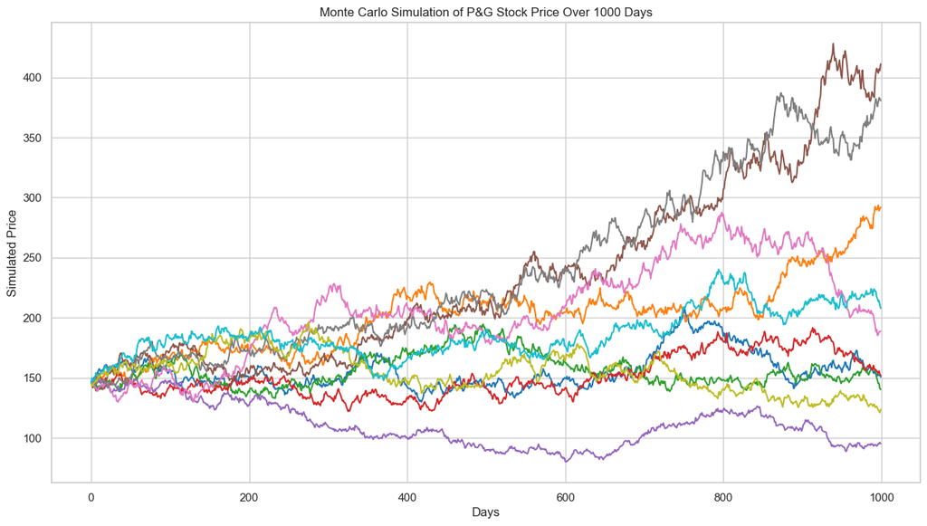

```python
plt.figure(figsize=(15,8))
plt.plot(price_list)
plt.title('Monte Carlo Simulation of P&G Stock Price Over 1000 Days')
plt.xlabel('Days')
plt.ylabel('Simulated Price')
plt.show()
```

1. **Plotting the Mean Prediction**  
   In this section, we calculate and plot the mean of our 10 predicted stock price paths over the next 1000 days. This will give us a single prediction path that represents the average outcome of our simulations.

```python
mean_prediction = np.mean(price_list, axis=1)
```

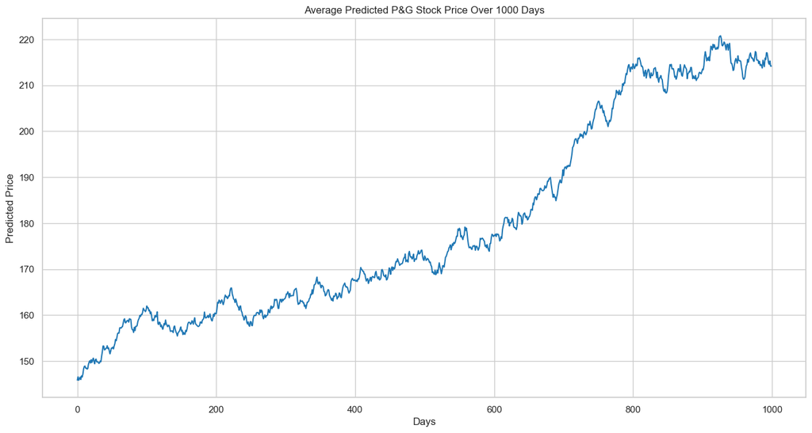

```python
plt.figure(figsize=(16,8))
plt.plot(mean_prediction)
plt.title('Average Predicted P&G Stock Price Over 1000 Days')
plt.xlabel('Days')
plt.ylabel('Predicted Price')
```